# Os 3 tipos de filmes por proporção de gêneros

Erick Santana Rodrigues

# Os Dados

Para a nossa análise teremos à disposição uma série de informações a respeito de 1662 filmes presentes no banco de dados do site [IMDB](https://www.imdb.com).

```r
cl <-read_csv(here("data/character_list5.csv"),
                      progress = FALSE,
                      col_types = cols(
                                    script_id = col_integer(),
                                    imdb_character_name = col_character(),
                                    words = col_integer(),
                                    gender = col_character(),
                                    age = col_character()
                                    ))

md <- read_csv(here("data/meta_data7.csv"),
                      progress = FALSE,
         col_types = cols(
                        script_id = col_integer(),
                        imdb_id = col_character(),
                        title = col_character(),
                        year = col_integer(),
                        gross = col_integer(),
                        lines_data = col_character()
                        )) %>%
  mutate(title = iconv(title,"latin1", "UTF-8"))

movies <- left_join(cl,
          md,
          by=c("script_id")) %>%
          group_by(title) %>%
          drop_na(gross)
```

Antes de usar os dados, irei fazer algumas alterações, criando novas variáveis e eliminando outras. Além de realizar uma filtragem para usar apenas filmes recentes, isto é, de 2010 em diante.

```r
movies <- movies %>%
    group_by(title, year, gross) %>%
  summarise(
            fem_words = sum(ifelse(gender == "f",words,0)),
            man_words = sum(ifelse(gender == "m",words,0)),
            fem = sum(gender == "f"),
            man = sum(gender == "m")) %>%
            filter(man_words != 0) %>%
            filter(fem_words != 0) %>%
            filter(gross != 0) %>%
            filter(year >= 2010)

movies <- movies[order(movies$year),]

movies
```

| title | year | gross | fem_words | man_words | fem | man |
| --- | --- | --- | --- | --- | --- | --- |
| 127 Hours | 2010 | 20 | 809 | 4336 | 3 | 1 |
| Alice in Wonderland | 2010 | 368 | 3515 | 1883 | 5 | 5 |
| Animal Kingdom | 2010 | 1 | 2051 | 6649 | 4 | 11 |
| Another Year | 2010 | 3 | 8280 | 5715 | 3 | 7 |
| Barney's Version | 2010 | 8 | 3448 | 7539 | 4 | 12 |
| Beginners | 2010 | 6 | 2502 | 8861 | 3 | 4 |
| Black Swan | 2010 | 117 | 2444 | 1947 | 4 | 1 |
| Blue Valentine | 2010 | 10 | 2694 | 5025 | 4 | 7 |
| Buried | 2010 | 1 | 869 | 13700 | 3 | 6 |
| Burlesque | 2010 | 43 | 10788 | 7068 | 7 | 7 |

[output cut: 372 more lines]

Finalmente, nos nossos dados temos as seguintes variáveis para cada filme:

Title - Título do filme.  
Year - Ano de lançamento.  
Gross - Bilheteria (em dólares).  
Fem_words - Quantidade de falas femininas.  
Man_words - Quantidade de falas masculinas.  
fem - Quantidade de personagens femininos  
man - Quantidade de personagens masculinos

Tendo então esses dados, a dúvida que surge é se é possível classificar diferentes grupos de filmes levando em consideração a proporção de falas masculinas e femininas, bilheteria e quantidade de homens e mulheres no filme.

# Estatística GAP

A GAP compara a solução do agrupamento com cada k com a solução em um dataset onde não há estrutura de grupos. Vamo utilizar essa medida para descobrir uma quantidade ideal de grupos na qual podemos dividir os dados.

## Escalonando dados

Antes de continuar é necessário aplicar uma escala apropriada para os nossos dados.

```r
scaled_movies <- movies %>%
  group_by(title) %>%
  ungroup() %>%
  select(title,
         gross,
         fem_words,
         man_words,
         fem,
         man)

scaled_movies <- scaled_movies %>%
                    mutate(gross = log10(gross),
                           fem_words = log10(fem_words),
                           man_words = log10(man_words),
                           fem = log10(fem),
                           man = log10(man))
```

## K ótimo

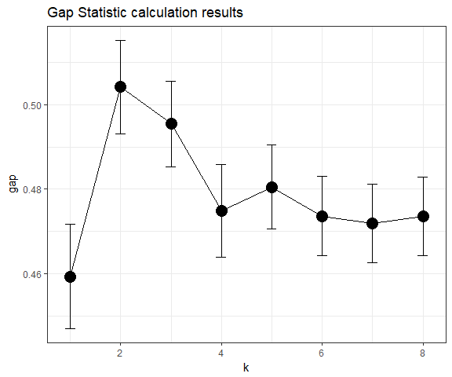

```r
plot_clusgap = function(clusgap, title="Gap Statistic calculation results"){
    require("ggplot2")
    gstab = data.frame(clusgap$Tab, k=1:nrow(clusgap$Tab))
    p = ggplot(gstab, aes(k, gap)) + geom_line() + geom_point(size=5)
    p = p + geom_errorbar(aes(ymax=gap+SE.sim, ymin=gap-SE.sim), width = .2)
    p = p + ggtitle(title)
    return(p)
}

gaps <- scaled_movies %>%
    select(-title)%>%
    clusGap(FUN = kmeans,
            nstart = 100,
            K.max = 8,
            B = 200,
            iter.max=30)

plot_clusgap(gaps)
```

# Agrupamento

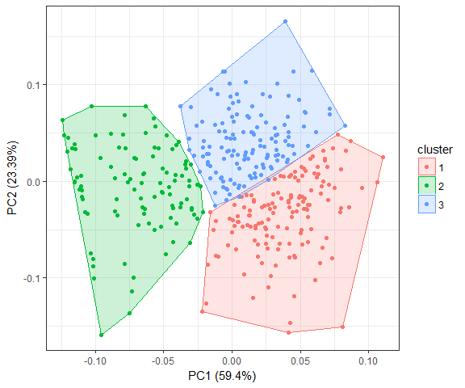

```r
set.seed(31)
features <- c('gross', 'fem_words', 'man_words', 'fem', 'man')

k <- kmeans(scaled_movies[, features], 3, nstart = 20)

autoplot(k, data=scaled_movies, frame = TRUE)
```

É possível ver a presença dos 3 grupos de maneira muito clara e com apenas um pequeno overlap entre os grupos 1 e 3

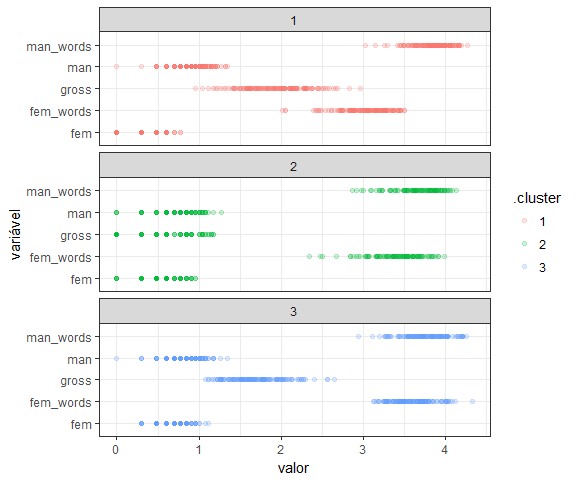

```r
set.seed(31)

km = scaled_movies %>%
    select(-title) %>%
    kmeans(centers = 3, nstart = 20)

km %>%
    augment(scaled_movies) %>%
    gather(key = "variável", value = "valor", -title, -.cluster) %>%
    ggplot(aes(x = `variável`, y = valor, group = title, colour = .cluster)) +
    geom_point(alpha = 0.2) +
    facet_wrap(~ .cluster, nrow = 3) +
    coord_flip()
```

Os 3 grupos se comportam de forma parecida como pode ser observado, porém nós podemos classifica-los da seguinte maneira:

Grupo vermelho:

- Um grupo com uma quantidade bem menor de mulheres em comparação com os homens e com bem menos falas para elas. O faturamento dos filmes nesse grupo é médio porém ocupa muito espaço, caminhando entre faturamentos altos e baixos.

Grupo verde:

- Um grupo cujos filmes tem faturamento baixo e a quantidade de homens e mulheres é parecida, a quantidade de falas para ambos os sexos é alta e bem parecida, porém para as mulheres essa quantidade atinge valores menores.

Grupo azul:

- Um grupo com uma quantidade menor de personagens femininas, mas ainda assim próxima da quantidade de personagens masculinos. Com um faturamento razoável, puxando para o lado esquerdo e uma quantidade de falas alta e parecida para ambos os sexos.